# Redes Neuronales

# Clasificar datos escritos a mano

#### Pre-requisitos:

Vamos a necesitar la siguientes librerias. Ojo se instalan de manera distinta que la mayoría de los paquetes en r. (Recuerden también cargar tidyverse para la manipulación de los datos)

```r
install.packages("tensorflow")
library(tensorflow)
install_tensorflow()
install.packages("keras")
library(keras)
install_keras()
```

Qué son estas dos librerias?

- Tensorflow: libreria open source para modelos de ML [info](https://tensorflow.rstudio.com/)
- Keras: API de redes neuronales [info](https://keras.rstudio.com/)

#### Datos

Los datos los pueden encontrar acá en formato .cvs [click aqui](https://pjreddie.com/projects/mnist-in-csv/). Useremos solo los datos de entrenamiento así que descarguen el train set.

```r
raw_data <- read_csv("mnist_train.csv",col_names = FALSE)
dim(raw_data)
```

```
## [1] 60000   785
```

```r
head(raw_data)
```

```
## # A tibble: 6 x 785
##      X1    X2    X3    X4    X5    X6    X7    X8    X9   X10   X11   X12   X13
##   <dbl> <dbl> <dbl> <dbl> <dbl> <dbl> <dbl> <dbl> <dbl> <dbl> <dbl> <dbl> <dbl>
## 1     5     0     0     0     0     0     0     0     0     0     0     0     0
## 2     0     0     0     0     0     0     0     0     0     0     0     0     0
## 3     4     0     0     0     0     0     0     0     0     0     0     0     0
## 4     1     0     0     0     0     0     0     0     0     0     0     0     0
## 5     9     0     0     0     0     0     0     0     0     0     0     0     0
## 6     2     0     0     0     0     0     0     0     0     0     0     0     0
## # … with 772 more variables: X14 <dbl>, X15 <dbl>, X16 <dbl>, X17 <dbl>,
## #   X18 <dbl>, X19 <dbl>, X20 <dbl>, X21 <dbl>, X22 <dbl>, X23 <dbl>,
## #   X24 <dbl>, X25 <dbl>, X26 <dbl>, X27 <dbl>, X28 <dbl>, X29 <dbl>,
## #   X30 <dbl>, X31 <dbl>, X32 <dbl>, X33 <dbl>, X34 <dbl>, X35 <dbl>,
## #   X36 <dbl>, X37 <dbl>, X38 <dbl>, X39 <dbl>, X40 <dbl>, X41 <dbl>,
## #   X42 <dbl>, X43 <dbl>, X44 <dbl>, X45 <dbl>, X46 <dbl>, X47 <dbl>,
## #   X48 <dbl>, X49 <dbl>, X50 <dbl>, X51 <dbl>, X52 <dbl>, X53 <dbl>,
## #   X54 <dbl>, X55 <dbl>, X56 <dbl>, X57 <dbl>, X58 <dbl>, X59 <dbl>,
## #   X60 <dbl>, X61 <dbl>, X62 <dbl>, X63 <dbl>, X64 <dbl>, X65 <dbl>,
## #   X66 <dbl>, X67 <dbl>, X68 <dbl>, X69 <dbl>, X70 <dbl>, X71 <dbl>,
## #   X72 <dbl>, X73 <dbl>, X74 <dbl>, X75 <dbl>, X76 <dbl>, X77 <dbl>,
## #   X78 <dbl>, X79 <dbl>, X80 <dbl>, X81 <dbl>, X82 <dbl>, X83 <dbl>,
## #   X84 <dbl>, X85 <dbl>, X86 <dbl>, X87 <dbl>, X88 <dbl>, X89 <dbl>,
## #   X90 <dbl>, X91 <dbl>, X92 <dbl>, X93 <dbl>, X94 <dbl>, X95 <dbl>,
## #   X96 <dbl>, X97 <dbl>, X98 <dbl>, X99 <dbl>, X100 <dbl>, X101 <dbl>,
## #   X102 <dbl>, X103 <dbl>, X104 <dbl>, X105 <dbl>, X106 <dbl>, X107 <dbl>,
## #   X108 <dbl>, X109 <dbl>, X110 <dbl>, X111 <dbl>, X112 <dbl>, X113 <dbl>, …
```

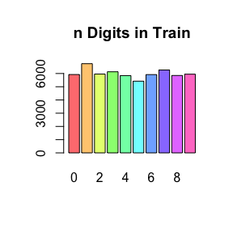

```r
barplot(table(raw_data[,1]), col=rainbow(10, 0.5), main="n Digits in Train")
```

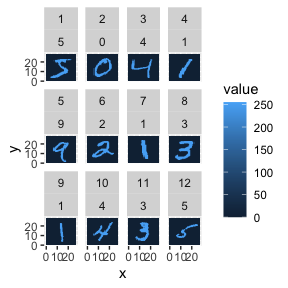

```r
pixels_gathered <- raw_data %>%
  head(10000) %>%
  rename(label = X1) %>%
  mutate(instance = row_number()) %>%
  gather(pixel, value, -label, -instance) %>%
  tidyr::extract(pixel, "pixel", "(\\d+)", convert = TRUE) %>%
  mutate(pixel = pixel - 2,
         x = pixel %% 28,
         y = 28 - pixel %/% 28)
pixels_gathered %>%
  filter(instance <= 12) %>%
  ggplot(aes(x, y, fill = value)) +
  geom_tile() +
  facet_wrap(~ instance + label)
```

#### Preparar los datos

Vamos a dividir nuestros datos en 2 conjuntos distintos: entrenamiento y prueba. El conjunto de entrenamiento es el 80% del nuestra base original y el 20% restante es el conjunto de prueba. Vamos a dividir cada uno de estos conjuntos es y y x. Donde y contiene la clasificación del dígito y x es el valor para cada uno de los pixeles.

```r
idx <- sample(seq(1, 2), size = nrow(raw_data), replace = TRUE, prob = c(.8, .2))
train <- raw_data[idx == 1,]
test <- raw_data[idx == 2,]
train_x <- train %>% select(-X1) %>% as.matrix()
train_y <- train %>% select(X1) %>% as.matrix()
test_x <- test %>% select(-X1) %>% as.matrix()
test_y <- test %>% select(X1) %>% as.matrix()
```

```r
train_y <- to_categorical(train_y,10)
test_y <- to_categorical(test_y,10)
```

#### Definir y configurar el modelo

```r
model <- keras_model_sequential()
model %>%
  layer_dense(units = 15, activation = "sigmoid", input_shape = c(784)) %>%
  layer_dense(units = 10, activation = "sigmoid")
summary(model)
```

```
## Model: "sequential"
## ________________________________________________________________________________
## Layer (type)                        Output Shape                    Param #
## ================================================================================
## dense_1 (Dense)                     (None, 15)                      11775
## ________________________________________________________________________________
## dense (Dense)                       (None, 10)                      160
## ================================================================================
## Total params: 11,935
## Trainable params: 11,935
## Non-trainable params: 0
## ________________________________________________________________________________
```

```r
model %>% compile(
  loss = 'mean_squared_error',
  optimizer = "sgd",
  metrics = c('accuracy')
)
```

#### Entrenar el modelo

Utilizar fit para estimar los parámetros de la red. Aquí definimos el tamaño de los mini-batches y la cantidades de ephocs que queremos correr

```r
fit_digits <- model %>% fit(
  train_x, train_y,
  epochs = 30,
  batch_size = 128,
  validation_split = 0.2
)
```

Ya que estimamos todos los parámetros podemos evaluar como lo hizo el modelo

```r
model %>% evaluate(train_x, train_y)
```

```
##       loss   accuracy
## 0.08381006 0.45326257
```

```r
model %>% evaluate(test_x, test_y)
```

```
##       loss   accuracy
## 0.08389197 0.44926810
```

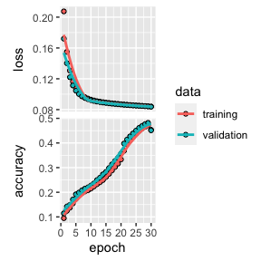

```r
plot(fit_digits)
```

Si queremos encontrar solo las y’s estimadas basta con

```r
y_hat <- model %>% predict(test_x)
head(y_hat)
```

```
##           [,1]      [,2]       [,3]      [,4]      [,5]       [,6]       [,7]
## [1,] 0.2589047 0.1289181 0.17037573 0.1652392 0.1810430 0.08745638 0.10311884
## [2,] 0.1441595 0.1249184 0.09271863 0.2096734 0.1246435 0.18349916 0.08420902
## [3,] 0.1370510 0.1652269 0.17183155 0.1184002 0.1417069 0.10155216 0.18918690
## [4,] 0.1170734 0.1234668 0.12230778 0.1618351 0.1210621 0.17160794 0.10699084
## [5,] 0.1441595 0.1249184 0.09271863 0.2096734 0.1246435 0.18349916 0.08420902
## [6,] 0.1519932 0.1351438 0.09517610 0.1375602 0.1074617 0.11090344 0.09876791
##           [,8]      [,9]      [,10]
## [1,] 0.1386328 0.1369902 0.12376547
## [2,] 0.1122321 0.1577967 0.20226735
## [3,] 0.1220132 0.1272284 0.08505201
## [4,] 0.1490632 0.1159396 0.17480260
## [5,] 0.1122321 0.1577967 0.20226735
## [6,] 0.1150666 0.1365247 0.12637997
```

Si queremos encontrar cual es el dígito que el modelo predice solo necesitamos manipular un poco este objeto.

```r
y_hat <- as.data.frame(y_hat)
y_hat <- y_hat %>%
  mutate(digit = max.col(y_hat))
```

Este es el código básico, ahora podemos evaluar que pasa si cambiamos cosas como la cantidad de ephocs, agregamos métodos de regularización, agregamos nodos a nuestra capa intermedia o agregamos más capas.

#### Cómo podemos mejorar nuestra red?

##### Cambiando nuestra función de costos

Solo necesitamos cambiar la función y dejaremos la estructura de la red intacta.

```r
model %>% compile(
  loss = 'categorical_crossentropy',
  optimizer = "sgd",
  metrics = c('accuracy')
)
```

Evaluamos como lo hace con respecto a la primera:

```r
model %>% fit(
  train_x, train_y,
  epochs = 30,
  batch_size = 128,
  validation_split = 0.2
)
model %>% evaluate(train_x, train_y)
```

```
##      loss  accuracy
## 0.4436182 0.8820481
```

```r
model %>% evaluate(test_x, test_y)
```

```
##      loss  accuracy
## 0.4598871 0.8767043
```

##### Cambiando nuestra función de activación en la última capa

```r
model <- keras_model_sequential()
model %>%
  layer_dense(units = 15, activation = "sigmoid", input_shape = c(784)) %>%
  layer_dense(units = 10, activation = "softmax")
model %>% compile(
  loss = 'mean_squared_error',
  optimizer = "sgd",
  metrics = c('accuracy')
)
```

Evaluamos como lo hace con respecto a la primera:

```r
model %>% fit(
  train_x, train_y,
  epochs = 30,
  batch_size = 128,
  validation_split = 0.2
)
model %>% evaluate(train_x, train_y)
```

```
##       loss   accuracy
## 0.06806947 0.58108026
```

```r
model %>% evaluate(test_x, test_y)
```

```
##       loss   accuracy
## 0.06806426 0.57917190
```

##### Regularización

Vamos a usar dropout en nuestra red original y ver si esto mejora la precisión

```r
model <- keras_model_sequential()
model %>%
  layer_dense(units = 15, activation = "sigmoid", input_shape = c(784)) %>%
  layer_dropout(rate = 0.5) %>%
  layer_dense(units = 10, activation = "sigmoid")
model %>% compile(
  loss = 'mean_squared_error',
  optimizer = "sgd",
  metrics = c('accuracy')
)
```

Evaluamos como lo hace nuestra nueva red

```r
model %>% fit(
  train_x, train_y,
  epochs = 30,
  batch_size = 128,
  validation_split = 0.2
)
model %>% evaluate(train_x, train_y)
```

```
##       loss   accuracy
## 0.08752341 0.20029140
```

```r
model %>% evaluate(test_x, test_y)
```

```
##       loss   accuracy
## 0.08757532 0.19740695
```

##### Qué pasa si agregamos estos tres cambios juntos?

```r
model <- keras_model_sequential()
model %>%
  layer_dense(units = 15, activation = "sigmoid", input_shape = c(784)) %>%
  layer_dropout(rate = 0.5) %>%
  layer_dense(units = 10, activation = "softmax")
model %>% compile(
  loss = 'categorical_crossentropy',
  optimizer = "sgd",
  metrics = c('accuracy')
)
```

Evaluamos como lo hace nuestra nueva red

```r
fit_NN <- model %>% fit(
  train_x, train_y,
  epochs = 30,
  batch_size = 128,
  validation_split = 0.2
)
model %>% evaluate(train_x, train_y)
```

```
##      loss  accuracy
## 0.7500808 0.8434801
```

```r
model %>% evaluate(test_x, test_y)
```

```
##      loss  accuracy
## 0.7510749 0.8433291
```

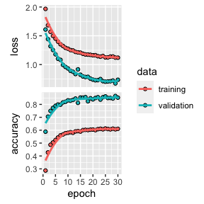

```r
plot(fit_NN)
```

#### Deep Learning

Hasta ahora nuestra red ha tenido una sola copa intermedia. Agregar más capas es muy sencillo solo necesitamos declararlas en el modelo original.

```r
model <- keras_model_sequential()
model %>%
  layer_dense(units = 15, activation = 'sigmoid', input_shape = c(784)) %>%
  layer_dropout(rate = 0.5) %>%
   layer_dense(units = 128, activation = 'sigmoid') %>%
  layer_dropout(rate = 0.3) %>%
  layer_dense(units = 10, activation = "softmax")
model %>% compile(
  loss = 'categorical_crossentropy',
  optimizer = "sgd",
  metrics = c('accuracy')
)
```

Evaluamos como lo hace nuestra nueva red

```r
model %>% fit(
  train_x, train_y,
  epochs = 30,
  batch_size = 128,
  validation_split = 0.2
)
model %>% evaluate(train_x, train_y)
```

```
##      loss  accuracy
## 0.9346854 0.7883235
```

```r
model %>% evaluate(test_x, test_y)
```

```
##      loss  accuracy
## 0.9376672 0.7904642
```

###### CNNs

```r
train_x_cnn <- array_reshape(train_x,
                               dim = c(nrow(train_x), 28, 28, 1)
                               )
test_x_cnn <- array_reshape(test_x,
                               dim = c(nrow(test_x), 28, 28, 1)
                               )
```

Definimos nuestra red con una sola convolución que recorre regiones de 3x3 nodos, seguida de una capa de pooling seguida por una capa completamente conectada (como todas las que hemos usado hasta ahora) con 15 nodos, la última capa es la de salida, igual que en los casos anteriores es una capa densa con 10 nodos de salida.

```r
modelcnn <- keras_model_sequential() %>%
   layer_conv_2d(filters = 32, kernel_size = c(3,3), activation = 'sigmoid',
                input_shape = c(28, 28, 1))%>%
  layer_max_pooling_2d(pool_size = c(3,3)) %>%
  layer_dropout(rate = 0.25) %>%
  layer_flatten() %>%
  layer_dense(units = 15, activation = 'sigmoid') %>%
  layer_dropout(rate = 0.5) %>%
  layer_dense(units = 10, activation = 'sigmoid')
```

Definimos la función de costos, el método de optimización y la métrica.

```r
modelcnn %>% compile(
  loss = "categorical_crossentropy",
  optimizer = "adam",
  metrics = "accuracy"
)
```

Por último entrenamos el modelo:

```r
CNN <- modelcnn %>% fit(
  train_x_cnn, train_y,
  epochs = 5,
  batch_size = 128,
  validation_split = 0.2
)
modelcnn %>% evaluate(train_x_cnn, train_y)
```

```
##      loss  accuracy
## 0.4715815 0.9415340
```

```r
modelcnn %>% evaluate(test_x_cnn, test_y)
```

```
##      loss  accuracy
## 0.4733958 0.9420326
```

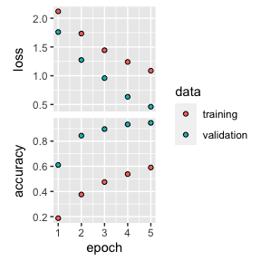

```r
plot(CNN)
```